# Analiza skupa hapsenja u Njujorku

#### Evaluacija preciznosti unakrsnom validacijom

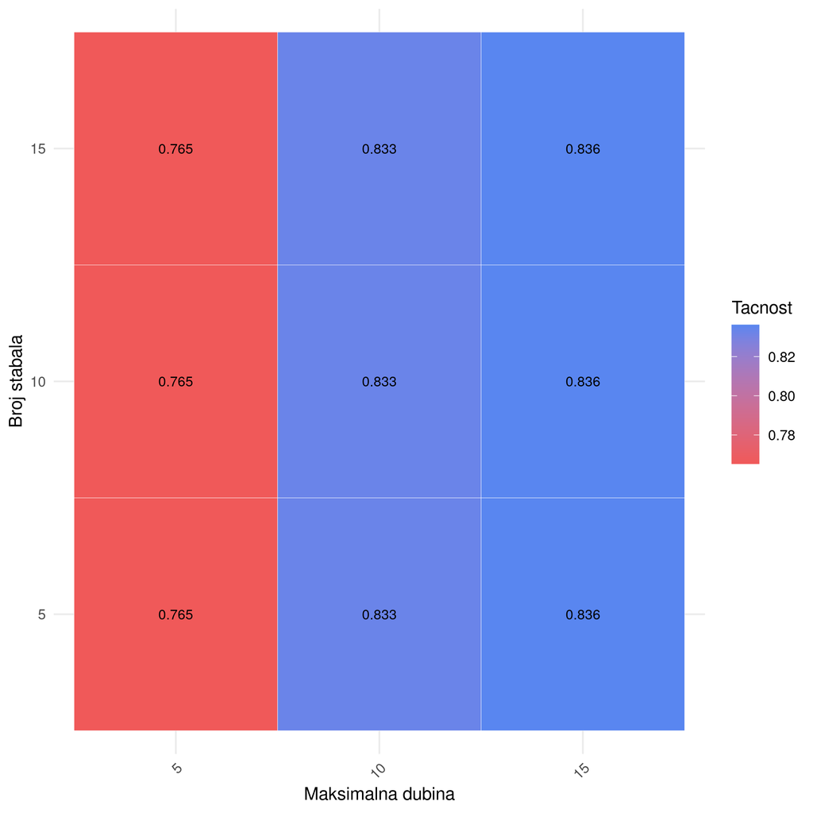

```r
pip <- sc %>%
    ml_pipeline() %>%
    ft_r_formula(formula) %>%
    ml_random_forest_classifier()

param_grid <- list(
  random_forest_classifier = list(
    max_depth = max_depths,
    num_trees = tree_count
  )
)

evaluator <- ml_multiclass_classification_evaluator(
  x=sc,
  metric_name="accuracy"
)

validator <- ml_cross_validator(
  x=sc,
  estimator=pip,
  evaluator=evaluator,
  estimator_param_maps=param_grid,
  num_folds=5
)

fit <- ml_fit(x = validator, dataset = df)
metrics <- ml_validation_metrics(fit)

p <- ggplot(metrics, aes(x = factor(max_depth_1), y = factor(num_trees_1), fill = accuracy, label = round(accuracy, 3))) +
  geom_tile(color = "white") +
  scale_fill_gradient(low = "#f05959", high = "#5986f0") +
  labs(x = "Maksimalna dubina", y = "Broj stabala", fill = "Tacnost") +
  theme_minimal() +
  theme(axis.text.x = element_text(angle = 45, hjust = 1)) +
  geom_text(size = 3, color = "black")

ggsave("assets/rf_k_fold_validation.png", p)
```

### 4. Poredjenja tacnosti za sve scenarije

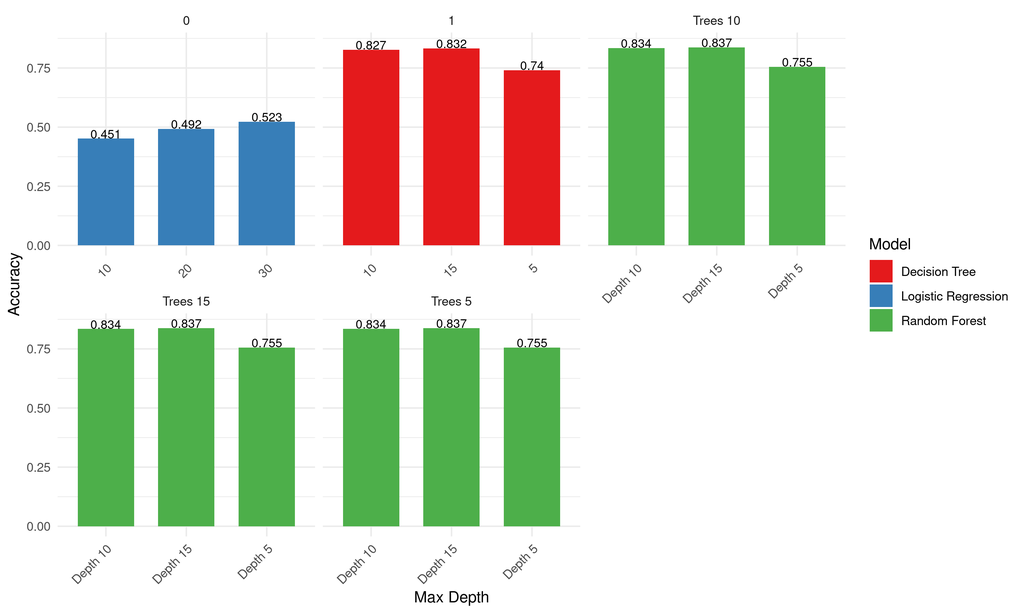

```r
rf_df <- as.data.frame(as.table(rf_accuracies))
colnames(rf_df) <- c("num_trees", "max_depth", "accuracy")
rf_df$model <- "Random Forest"

dtc_df <- data.frame(
  num_trees = rep(1, length(max_depths)),
  max_depth = max_depths,
  accuracy = dtc_accuracies,
  model = "Decision Tree"
)

lr_df <- data.frame(
  num_trees = rep(0, length(max_depths)),
  max_depth = max_iters,
  accuracy = lr_accuracies,
  model = "Logistic Regression"
)

rf_df$num_trees <- as.character(rf_df$num_trees)
rf_df$max_depth <- as.character(rf_df$max_depth)
dtc_df$num_trees <- as.character(dtc_df$num_trees)
dtc_df$max_depth <- as.character(dtc_df$max_depth)
lr_df$num_trees <- as.character(lr_df$num_trees)
lr_df$max_depth <- as.character(lr_df$max_depth)

combined_df <- bind_rows(rf_df, dtc_df, lr_df)

p <- ggplot(combined_df, aes(x = max_depth, y = accuracy, fill = model, label = round(accuracy, 3))) +
  geom_bar(stat = "identity", position = position_dodge(width = 0.8), width = 0.7) +
  scale_fill_brewer(palette = "Set1") +
  labs(x = "Max Depth", y = "Accuracy", fill = "Model") +
  theme_minimal() +
  theme(axis.text.x = element_text(angle = 45, hjust = 1)) +
  geom_text(aes(y = accuracy + 0.02), position = position_dodge(width = 0.8), size = 3, color = "black") +
  facet_wrap(~ num_trees, scales = "free_x")

ggsave("assets/combined_model_accuracies.png", plot = p, width = 10, height = 6)
```

## Klasterizacija

### 1. Odabir broja centroida

```r
clustered <- list()

min_cluster_count <- 2L
max_cluster_count <- 10L
search_field <- max_cluster_count - min_cluster_count + 1

for (cluster_count in min_cluster_count:max_cluster_count) {
  clustered[[cluster_count]] <- ml_bisecting_kmeans(
    x = df, formula = formula,
    k = cluster_count, max_iter = 20
  )
}

k_errors <- numeric(search_field)

for (i in min_cluster_count:max_cluster_count) {
  k_errors[i - min_cluster_count + 1] <- clustered[[i]]$cost
}

k_errors_df <- data.frame(
  clusters = min_cluster_count:max_cluster_count,
  SSE = k_errors
)

k_elbow_plot <- ggplot(k_errors_df, aes(x = clusters, y = SSE)) +
  geom_line() +
  geom_point() +
  labs(
    x = "Broj klastera",
    y = "Suma kvadrata gresaka (SSE)"
  ) +
  theme_minimal()

png_filename <- "assets/elbow_plot.png"
ggsave(
  filename = png_filename,
  plot = k_elbow_plot,
  width = 10,
  height = 6,
  dpi = 300
)
```

**Rezultujuci grafikon:**

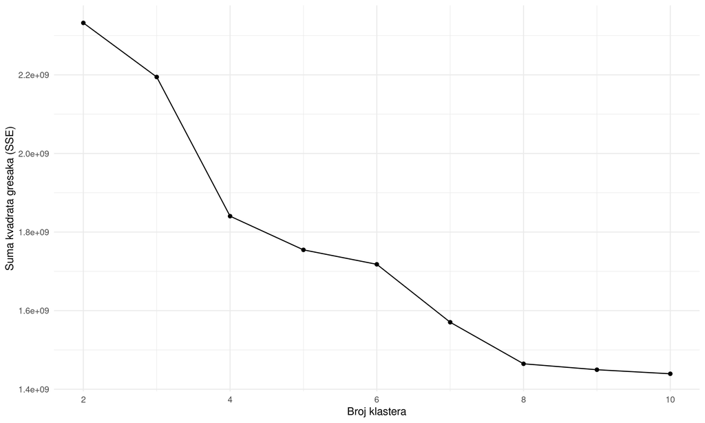

Na osnovu grafikona, za broj centgroida ce se uzeti **6** i **8**, za potrebe dva scenarija klasterizacije.

### 2. Racunanje centroida

```r
models <- list()
preds <- list()

clusterisation_size <- c(1:2)
centroid_count <- c(6, 8)

for (i in clusterisation_size) {
    models[[i]] <- ml_bisecting_kmeans(x = df, formula = formula, k = centroid_count[i], max_iter = 20)
    preds[[i]] <- ml_predict(models[[i]], newdata = df)
}
```

```r
sampled_preds1 <- preds[[1]] %>% sample_n(10000)
centroids <- models[[1]]$centers

centroids_df <- data.frame(
  State_Bottle_Cost = centroids$State_Bottle_Cost,
  Volume_Sold_Liters = centroids$Volume_Sold_Liters
)

plot_1 <- ggplot() +
  geom_point(data = sampled_preds1, aes(x = State_Bottle_Cost, y = Volume_Sold_Liters, color = factor(prediction))) +
  geom_point(data = centroids_df, aes(x = State_Bottle_Cost, y = Volume_Sold_Liters), color = "black", size = 1) +
  labs(
    x = "Cena flase",
    y = "Zapremina u litrima",
    color = "Klaster"
  ) +
  scale_color_manual(values = c("#1f77b4", "#ff7f0e", "#2ca02c", "#d62728", "#9467bd", "#8c564b")) +
  theme_minimal()

png_filename <- "assets/6_centroid_clustering.png"
ggsave(
  filename = png_filename,
  plot = plot_1,
  width = 10, height = 6, dpi = 300
)
```

### 3. Vizuelizacija odnosa izmedju vrednosti obelezja i pripadnosti klasteru

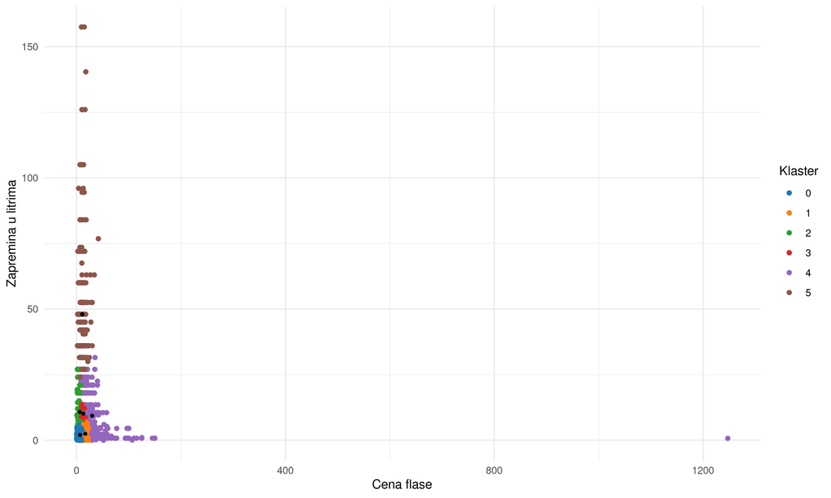

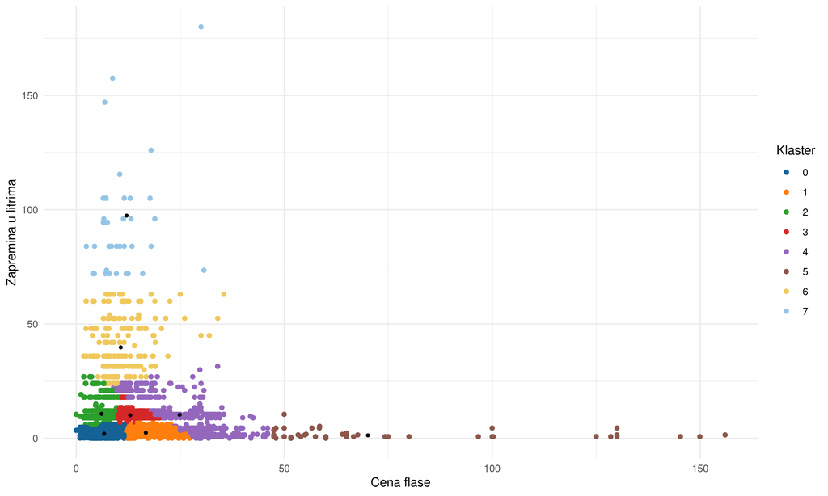

### 4. Prikaz strukture klastera

```r
sample_df <- preds[[1]] %>%
  sample_n(50000) %>%
  collect()

columns_to_drop <- c("features", "label")

sample_df <- sample_df[!colnames(sample_df) %in% columns_to_drop]

summary_df <- sample_df %>%
  rename(cluster = prediction) %>%
  group_by(cluster) %>%
  summarise(
    across(
      everything(),
      list(
        mean = ~ round(mean(.), 2),
        min = ~ round(min(.), 2),
        max = ~ round(max(.), 2),
        median = ~ round(median(.), 2),
        sd = ~ round(sd(.), 2)
      ),
      .names = "{col}_{fn}"
    )
  )

transposed_df <- summary_df %>%
  gather(key = "Statistika", value = "Value", -cluster) %>%
  spread(key = cluster, value = Value)

cluster_structure <- kable(transposed_df, "html")

writeLines(cluster_structure, "assets/cluster_structure_6.html")
```

**Statistika vrednosti obelezja po klasterima, 6 centroida:**

[interactive chart not shown]

**Statistika vrednosti obelezja po klasterima, 8 centroida:**

[interactive chart not shown]

## Izvestaj

1. Inicijalni zadrzano je 30% originalne velicine skupa, sto je rezultovalo u **8706351 redova**.
2. U fazi obrade skupa podataka izbacene su sve kolone koje nisu bile relevantne za dalji rad.
3. Raspodele nad pojedinacnim obilezjima nisu pogodne za graficki prikaz zbog nejednakog odnosa vrednosti na osama i `x` i `y`.
4. Iz korelacione matrice preostalih obelezja uocena je *relativno* velika obrnuta korelacija izmedju obelezja `State_Bottle_Cost`, `Bottle_Volume_ml`, te obelezja `Bottles_Sold`.
5. Na osnovu prethodne tacke izvucena je **formula za klasifikaciju i klasterizaciju**: `Bottles_Sold ~ State_Bottle_Cost + Volume_Sold_Liters`
6. Klasifikacija je vrsena na tri nacina:
   1. `Stabla odlucivanja`
   2. `Logisticka regresija`
   3. `Random forest`
7. Klasterizacija je vrsena pomocu `k-means`, sa **6** i **8** centroida.

#### Dodatna tumacenja

##### Klasterizacija

Zbog primecenog pada sume kvadrata gresaka (**SSE**) pri broja centroida **6 i 8**, upravo je odabran ovaj broj centroida za dva scenarija klasterizacije. Rezultati klasterizacije su bili prikazani vizuelno ali izvucen je i statisticki uvid za sva obilezja svakog klastera.